# STSCI 5060 - Final Project - Summary

# Step 1

1. cmd

```
SQLPLUS
Da
******
CREATE USER Lu_Da_STSCI5060FP IDENTIFIED BY 950511;
GRANT ALL PRIVILEGES TO Lu_Da_STSCI5060FP;
```

2. Oracle SQL Developer

```
Connection Name: Lu_Da_STSCI5060FP
      User Name: Lu_Da_STSCI5060FP
       Password: ******
```

# Step 2

Import `State_Code.csv` data as `State_t`.

StCode: VARCHAR2(2)  
StName: VARCHAR2(26)  
StAbb: CHAR(2)

[figure not shown]

[figure not shown]

# Step 3

Update the first 9 StCode by adding 0 in the front.

*SQL Developer*

```
/* Update the first 9 StCode by adding 0 in the front. */
UPDATE State_t
    SET StCode = '0' || substr(StCode,1,1)
    WHERE CAST(StCode AS NUMBER(2)) <= 9;

/* Display the first 9 rows. */
SELECT * FROM State_t
    WHERE ROWNUM <= 9;
```

# Step 4

*SAS*

```
Libname Final "C:\Users\Harry Lu's X1\Documents\Cornell\STSCI 5060\Final Project";

Libname myoracle Oracle User = "Lu_Da_STSCI5060FP" Password = "950511" Path = "xe";
RUN;

PROC SQL;
    Create Table myoracle.School_Finance_2010_t As
        Select * From Final.School_Finance_2010;
QUIT;

Libname myoracle Clear;
```

*SQL Developer*

```
/* Describe the table School_Finance_2010_t. */
DESCRIBE School_Finance_2010_t;

/* Display the first 10 rows. */
SELECT * FROM School_Finance_2010_t
    WHERE ROWNUM <= 10;
```

# Step 5

*SQL Developer*

```
/* Alter IDCensus to VARCHAR2(15). */
ALTER TABLE School_Finance_2010_t MODIFY IDCensus VARCHAR2(15);

/* Alter Name to VARCHAR2(60). */
ALTER TABLE School_Finance_2010_t MODIFY Name VARCHAR2(60);
```

# Step 6

*SQL Developer*

```
/* Rename Name to SD_Name. */
ALTER TABLE School_Finance_2010_t RENAME COLUMN Name TO SD_Name;

/* Rename State to StCode. */
ALTER TABLE School_Finance_2010_t RENAME COLUMN State TO StCode;
```

# Step 7

*SQL Developer*

```
/* Create table Fedrev_t. */
CREATE TABLE Fedrev_t AS
    SELECT IDCensus, StCode, (c14+c15+c16+c17+c18+c19+b11+c20+c25+c36+b10+b12+b13) AS Fed_Rev
    FROM School_Finance_2010_t;

/* Create table Strev_t. */
CREATE TABLE Strev_t As
    SELECT IDCensus, StCode, (c01+c04+c05+c06+c07+c08+c09+c10+c11+c12+c13+c24+c35+c38+c39) AS St_Rev
    FROM School_Finance_2010_t;

/* Create table Locrev_t. */
CREATE TABLE Locrev_t As
    SELECT IDCensus, StCode, (t02+t06+t09+t15+t40+t99+d11+d23+a07+a08+a09+a11+a13+a15+a20+a40+u11+u22+u30+u50+u97) As Loc_Rev
    FROM School_Finance_2010_t;

/* Create table School_t. */
CREATE TABLE School_t As
    SELECT IDCensus, StCode, SD_Name
    FROM School_Finance_2010_t;
```

# Step 8

*SQL Developer*

```
/* Set StCode as the primary key of State_t. */
ALTER TABLE State_t
    ADD CONSTRAINT State_PK PRIMARY KEY (StCode);

/* Set IDCensus as the primary key of Fedrev_t, Strev_t, Locrev_t, School_t. */
ALTER TABLE Fedrev_t
    ADD CONSTRAINT Fedrev_PK PRIMARY KEY (IDCensus);
ALTER TABLE Strev_t
    ADD CONSTRAINT Strev_PK PRIMARY KEY (IDCensus);
ALTER TABLE Locrev_t
    ADD CONSTRAINT Locrev_PK PRIMARY KEY (IDCensus);
ALTER TABLE School_t
    ADD CONSTRAINT School_PK PRIMARY KEY (IDCensus);

/* Set foreign keys. */
ALTER TABLE Fedrev_t
    ADD CONSTRAINT Fedrev_FK FOREIGN KEY (IDCensus)
        REFERENCES School_t (IDCensus);
ALTER TABLE Strev_t
    ADD CONSTRAINT Strev_FK FOREIGN KEY (IDCensus)
        REFERENCES School_t (IDCensus);
ALTER TABLE Locrev_t
    ADD CONSTRAINT Locrev_FK FOREIGN KEY (IDCensus)
        REFERENCES School_t (IDCensus);
ALTER TABLE School_t
    ADD CONSTRAINT School_FK FOREIGN KEY (StCode)
        REFERENCES State_t (StCode);
```

# Step 9

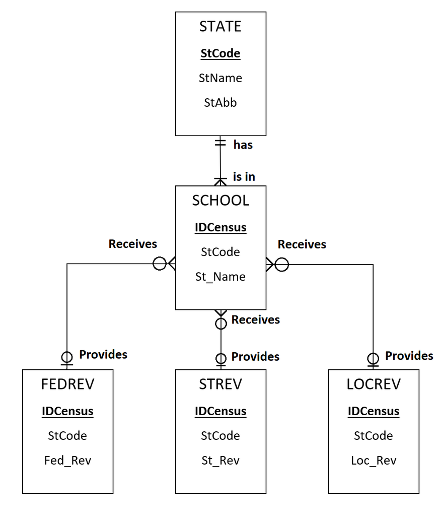

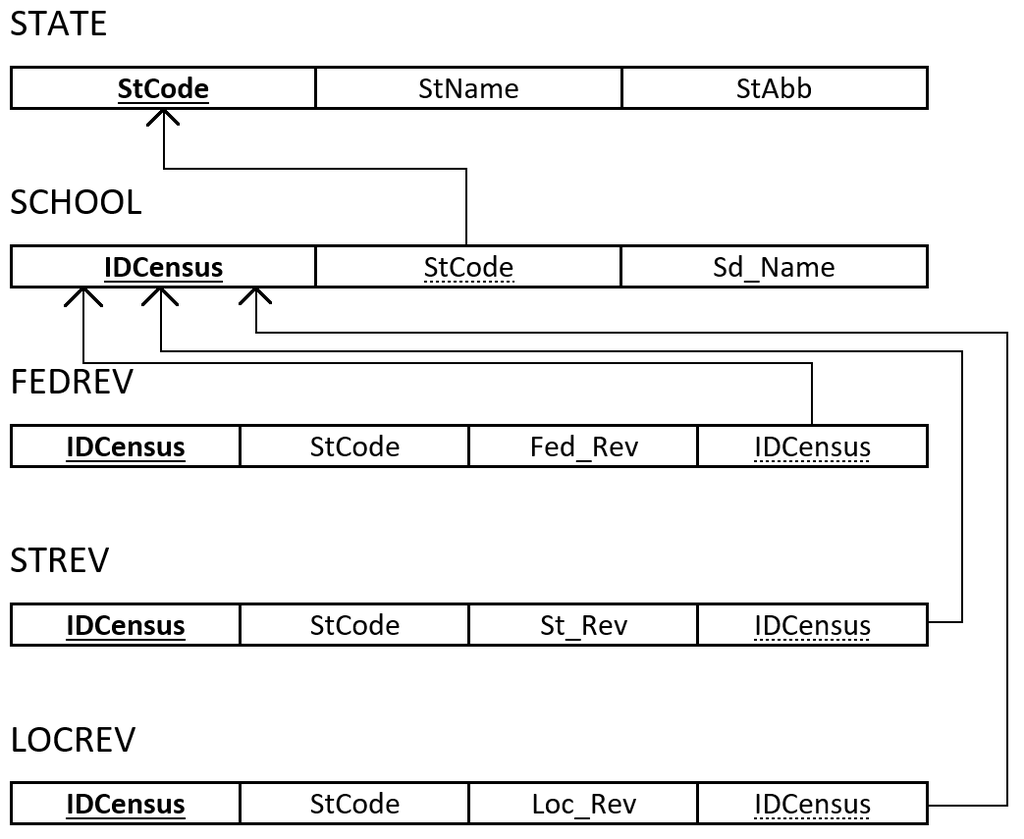

# Step 10

*SQL Developer*

```
/* Display the federal revenue which larger than 1,000,000. */
SELECT IDCensus, StCode, to_char(Fed_Rev,'999999999.9') AS Fed_Revenue FROM Fedrev_T
    WHERE Fed_Rev >= 1000000;

/* Display the state revenue which larger than 1,000,000. */
SELECT IDCensus, StCode, to_char(St_Rev,'999999999.9') AS St_Revenue FROM Strev_T
    WHERE St_Rev >= 1000000;

/* Display the local revenue which larger than 1,000,000. */
SELECT IDCensus, StCode, to_char(Loc_Rev,'999999999.9') AS Loc_Revenue FROM Locrev_T
    WHERE Loc_Rev >= 1000000;
```

# Step 11

*SQL Developer*

```
/* Create view called SD#_V. */
CREATE VIEW SD#_V AS
    SELECT COUNT(SD_Name) AS SD#, StCode
    FROM School_T
    GROUP BY StCode;

/* Display the states which have the most number of schools. */
SELECT State_T.StCode, StName, SD#
    FROM SD#_V, State_T
    WHERE SD#_V.StCode = State_T.StCode
        AND SD# = (SELECT MAX(SD#) FROM SD#_V);

/* Display the states which have the least number of schools. */
SELECT State_T.StCode, StName, SD#
    FROM SD#_V, State_T
    WHERE SD#_V.StCode = State_T.StCode
        AND SD# = (SELECT MIN(SD#) FROM SD#_V);
```

# Step 12

*SQL Developer*

```
/* Create views called mfr_V, msr_V, mlr_V respectively. */
CREATE VIEW mfr_V AS
    SELECT StCode, MAX(Fed_Rev) AS Max_Fed_Rev
    FROM Fedrev_T
    GROUP BY StCode
    ORDER BY StCode;
CREATE VIEW msr_V AS
    SELECT StCode, MAX(St_Rev) AS Max_St_Rev
    FROM Strev_T
    GROUP BY StCode
    ORDER BY StCode;
CREATE VIEW mlr_V AS
    SELECT StCode, MAX(Loc_Rev) AS Max_Loc_Rev
    FROM Locrev_T
    GROUP BY StCode
    ORDER BY StCode;
```

*SAS*

```
Libname myoracle Oracle User = "Lu_Da_STSCI5060FP" Password = "950511" Path = "xe";
RUN;

DATA myoracle.mfslr_t;
    Merge myoracle.mfr_v myoracle.msr_v myoracle.mlr_v;
    By StCode;
RUN;

Libname myoracle Clear;
```

*SQL Developer*

```
/* Display the combined table. */
SELECT to_char(mfslr_T.StCode,'999999999') AS StCode,
        to_char(Max_Fed_Rev,'999999999.9') AS Max_Fed_Rev,
        to_char(Max_St_Rev,'999999999.9') As Max_St_Rev,
        to_char(Max_Loc_Rev,'999999999.9') As Max_Loc_Rev,
        StName
    FROM mfslr_T, State_T
    WHERE mfslr_T.StCode = State_T.StCode;
```

# Step 13

*SQL Developer*

```
/* Add an extra column. */
SELECT to_char(mfslr_T.StCode,'999999999') AS State_Code,
        to_char(Max_Fed_Rev,'999999999.9') AS Max_Fed_Rev,
        StName AS State_Name,
        Sd_Name AS State_District_Name
    FROM mfslr_T, State_T, School_T, FedRev_T
    WHERE mfslr_T.StCode = State_T.StCode AND
            State_T.StCode = School_T.StCode AND
            School_T.StCode = mfslr_T.StCode AND
            School_T.IDCensus = FedRev_T.IDCensus AND
            School_T.IDCensus = (SELECT IDCensus FROM FedRev_T WHERE Fed_Rev = Max_Fed_Rev)
    ORDER BY Max_Fed_Rev DESC;
```

# Step 14

*SQL Developer*

```
/* Create a view: Total_Rev_V. */
CREATE VIEW Total_Rev_V AS
    SELECT FedRev_T.IDCensus, FedRev_T.StCode, Fed_Rev AS TFedRev, St_Rev AS TStRev, Loc_Rev AS TLocRev
    FROM FedRev_T, StRev_T, LocRev_T
    WHERE FedRev_T.IDCensus = StRev_T.IDCensus AND
            StRev_T.IDCensus = LocRev_T.IDCensus AND
            LocRev_T.IDCensus = FedRev_T.IDCensus;
```

# Step 15

*SQL Developer*

```
/* Display the Total_Revenue for each school district.*/
SELECT * FROM
    (SELECT to_char(Total_Rev_V.StCode,'999999999') AS StCode,
            StName,
            Total_Rev_V.IDCensus,
            to_char(TFedRev + TStRev + TLocRev,'99999999999.9') AS Total_Revenue,
            Sd_Name
        FROM Total_Rev_V, School_T, State_T
        WHERE Total_Rev_V.IDCensus = School_T.IDCensus AND
                Total_Rev_V.StCode = School_T.StCode AND
                School_T.StCode = State_T.StCode AND
                State_T.StCode = Total_Rev_V.StCode
        ORDER BY Total_Revenue DESC)
    WHERE ROWNUM <= 100;
```

# Step 16

*SQL Developer*

```
/* Total school expenditure of each state. */
SELECT to_char(School_Finance_2010_T.StCode,'999999') AS StCode,
        (SELECT StName FROM State_T WHERE State_T.StCode = School_Finance_2010_T.StCode) AS StName,
        to_char(SUM(TotalExp),'99999999.9') As TotalExpSt
    FROM School_Finance_2010_T
    GROUP BY StCode
    ORDER BY TotalExpSt DESC;
```

# Step 17

*SQL Developer*

**Note:** “RUN Script”

```
/* Total school expenditure of the year. */
SET HEADING OFF;
SELECT 'The total amount that the United States spent on the public school systems in 2010 was $',
        to_char(SUM(TotalExpSt),'999999999.9') As GrandTotal,
        ' K.'
    FROM (SELECT to_char(School_Finance_2010_T.StCode,'999999') AS StCode,
            (SELECT StName FROM State_T WHERE State_T.StCode = School_Finance_2010_T.StCode) AS StName,
            to_char(SUM(TotalExp),'99999999.9') As TotalExpSt
        FROM School_Finance_2010_T
        GROUP BY StCode
        ORDER BY TotalExpSt DESC);
SET HEADING ON;
```

# Step 18

*SQL Developer*

```
/* Create the view Fed_Contribution_V. */
CREATE VIEW Fed_Contribution_V AS
    SELECT FedRev_T.IDCensus,
            to_char(FedRev_T.StCode,'999999') AS StCode,
            Sd_Name,
            to_char(Fed_Rev/TotalExp,'9999.9999') AS Fed_pcnt
    FROM FedRev_T, School_Finance_2010_T
    WHERE FedRev_T.IDCensus = School_Finance_2010_T.IDCensus AND
            TotalExp > 0;
/* Display rows which have the ratio greater than 1. */
SELECT *
    FROM Fed_Contribution_V
    WHERE Fed_pcnt > 1
    ORDER BY Fed_pcnt DESC;

/* Create the view St_Contribution_V. */
CREATE VIEW St_Contribution_V AS
    SELECT StRev_T.IDCensus,
            to_char(StRev_T.StCode,'999999') AS StCode,
            Sd_Name,
            to_char(St_Rev/TotalExp,'9999.9999') AS St_pcnt
    FROM StRev_T, School_Finance_2010_T
    WHERE StRev_T.IDCensus = School_Finance_2010_T.IDCensus AND
            TotalExp > 0;
/* Display rows which have the ratio greater than 1. */
SELECT *
    FROM St_Contribution_V
    WHERE St_pcnt > 1
    ORDER BY St_pcnt DESC;

/* Create the view Loc_Contribution_V. */
CREATE VIEW Loc_Contribution_V AS
    SELECT LocRev_T.IDCensus,
            to_char(LocRev_T.StCode,'999999') AS StCode,
            Sd_Name,
            to_char(Loc_Rev/TotalExp,'9999.9999') AS Loc_pcnt
    FROM LocRev_T, School_Finance_2010_T
    WHERE LocRev_T.IDCensus = School_Finance_2010_T.IDCensus AND
            TotalExp > 0;
/* Display rows which have the ratio greater than 1. */
SELECT *
    FROM Loc_Contribution_V
    WHERE Loc_pcnt > 1
    ORDER BY Loc_pcnt DESC;
```

# Step 19

*SQL Developer*

```
/* Create the view fsl_Contribution_V. */
CREATE VIEW fsl_Contribution_V AS
    SELECT Fed_Contribution_V.IDCensus,
            to_char(Fed_Contribution_V.StCode,'999999') AS StCode,
            Fed_Contribution_V.Sd_Name,
            to_char((Fed_pcnt + St_pcnt + Loc_pcnt),'9999.9999') AS fsl_pcnt
    FROM Fed_Contribution_V, St_Contribution_V, Loc_Contribution_V
    WHERE Fed_Contribution_V.IDCensus = St_Contribution_V.IDCensus AND
            St_Contribution_V.IDCensus = Loc_Contribution_V.IDCensus AND
            Loc_Contribution_V.IDCensus = Fed_Contribution_V.IDCensus;

/* Display the school districts that received total revenues over 3 times of the total amount they spent. */
SELECT *
    FROM fsl_Contribution_V
    WHERE fsl_pcnt > 3
    ORDER BY fsl_pcnt DESC;

/* Display the school districts that received total revenues up to 0.3 times of the total amount they spent. */
SELECT *
    FROM fsl_Contribution_V
    WHERE fsl_pcnt < 0.3
    ORDER BY fsl_pcnt DESC;
```

# Step 20

*SAS*

```
Libname myoracle Oracle User = "Lu_Da_STSCI5060FP" Password = "950511" Path = "xe";
RUN;

PROC SQL;
    Create Table SASUser.Total_Rev As
        Select * From myoracle.Total_Rev_V;
QUIT;

Libname myoracle Clear;
```

# Step 21

*SAS*

```
PROC CORR Data = SASUser.Total_Rev Plots(maxpoints = none) = matrix(histogram);
    Var tfedrev tstrev tlocrev;
RUN;
```

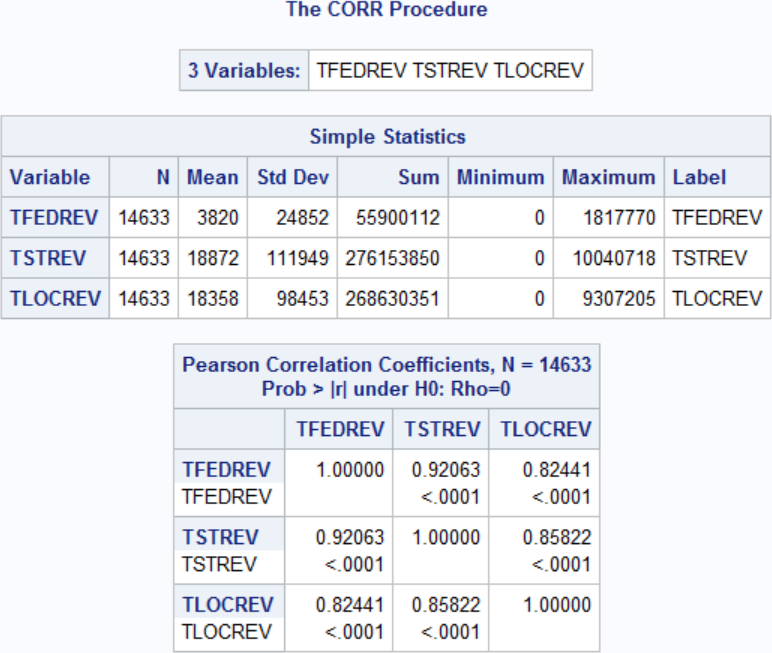

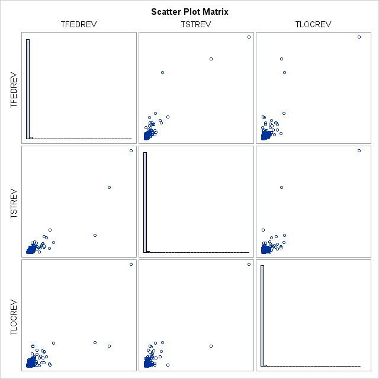

According to Pearson Correlation Coefficients, all those three variables seem correlated to each other. However, we cannot observe that from the Scatter Plot Matrix, because there are few outliers and most of the data points are chunked within a small range.

# Step 22

*SAS*

```
PROC REG Data = SASUser.Total_Rev;
    Model tfedrev = tstrev tlocrev;
RUN;
```

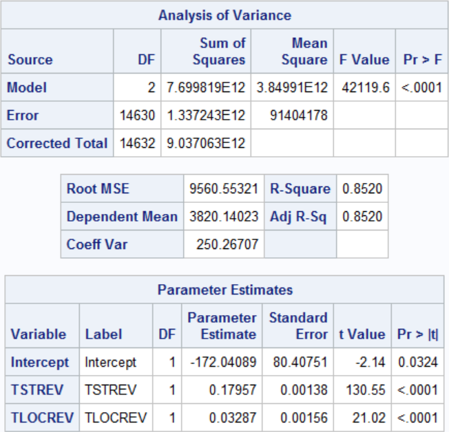

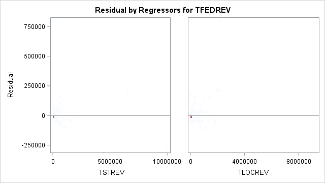

# Step 23

*SAS*

```
Libname myoracle Oracle User = "Lu_Da_STSCI5060FP" Password = "950511" Path = "xe";
RUN;

PROC CORR Data = myoracle.Total_Rev_V Plots(maxpoints = none) = matrix(histogram);
    Var tfedrev tstrev tlocrev;
RUN;
PROC REG Data = myoracle.Total_Rev_V;
    Model tfedrev = tstrev tlocrev;
RUN;

Libname myoracle Clear;
```

Because the SAS SQL Engine connects to the DBMS directly and processes the data from the database, this is an instance of in-database processing.

# Step 24

*SAS*

```
Libname Final "C:\Users\Harry Lu's X1\Documents\Cornell\STSCI 5060\Final Project";

Libname myoracle Oracle User = "Lu_Da_STSCI5060FP" Password = "950511" Path = "xe";
RUN;

PROC SQL;
    Create Table myoracle.School_Finance_2014_t As
        Select * From Final.School_Finance_2014;
QUIT;

Libname myoracle Clear;
```

# Step 25

*SQL Developer*

```
/* The top 10 school districts that had increased total revenues. */
SELECT * FROM (SELECT to_char(School_Finance_2010_T.StCode,'999999') AS StCode,
                        (SELECT StName
                            FROM State_T
                            WHERE State_T.StCode = School_Finance_2010_T.StCode AND
                            State_T.StCode = School_Finance_2014_T.State) AS StName,
                        School_Finance_2010_T.IDCensus,
                        School_Finance_2010_T.Sd_Name,
                        to_char((School_Finance_2014_T.TotalRev - School_Finance_2010_T.TotalRev),'99999999.9') AS RevDif,
                        to_char((100 * (School_Finance_2014_T.TotalRev - School_Finance_2010_T.TotalRev) / School_Finance_2010_T.TotalRev),'99999999999999.9') AS Change_Percentage
                    FROM School_Finance_2010_T, School_Finance_2014_T
                    WHERE School_Finance_2010_T.IDCensus = School_Finance_2014_T.IDCensus AND
                            School_Finance_2010_T.TotalRev > 0 AND
                            (100 * (School_Finance_2014_T.TotalRev - School_Finance_2010_T.TotalRev) / School_Finance_2010_T.TotalRev) > 0
                    ORDER BY Change_Percentage DESC)
    WHERE ROWNUM <= 10
    ORDER BY RevDif;

/* The top 10 school districts that had decreased total revenues. */
SELECT * FROM (SELECT to_char(School_Finance_2010_T.StCode,'999999') AS StCode,
                        (SELECT StName
                            FROM State_T
                            WHERE State_T.StCode = School_Finance_2010_T.StCode AND
                            State_T.StCode = School_Finance_2014_T.State) AS StName,
                        School_Finance_2010_T.IDCensus,
                        School_Finance_2010_T.Sd_Name,
                        to_char((School_Finance_2014_T.TotalRev - School_Finance_2010_T.TotalRev),'99999999.9') AS RevDif,
                        to_char((100 * (School_Finance_2014_T.TotalRev - School_Finance_2010_T.TotalRev) / School_Finance_2010_T.TotalRev),'99999999999999.9') AS Change_Percentage
                    FROM School_Finance_2010_T, School_Finance_2014_T
                    WHERE School_Finance_2010_T.IDCensus = School_Finance_2014_T.IDCensus AND
                            School_Finance_2010_T.TotalRev > 0 AND
                            (100 * (School_Finance_2014_T.TotalRev - School_Finance_2010_T.TotalRev) / School_Finance_2010_T.TotalRev) < 0
                    ORDER BY Change_Percentage DESC)
    WHERE ROWNUM <= 10
    ORDER BY RevDif;

/* All the school districts whose total revenus stayed the same. */
SELECT to_char(School_Finance_2010_T.StCode,'999999') AS StCode,
        (SELECT StName
            FROM State_T
            WHERE State_T.StCode = School_Finance_2010_T.StCode AND
            State_T.StCode = School_Finance_2014_T.State) AS StName,
        School_Finance_2010_T.IDCensus,
        School_Finance_2010_T.Sd_Name,
        to_char((School_Finance_2014_T.TotalRev - School_Finance_2010_T.TotalRev),'99999999.9') AS RevDif,
        to_char((100 * (School_Finance_2014_T.TotalRev - School_Finance_2010_T.TotalRev) / School_Finance_2010_T.TotalRev),'99999999999999.9') AS Change_Percentage
    FROM School_Finance_2010_T, School_Finance_2014_T
    WHERE School_Finance_2010_T.IDCensus = School_Finance_2014_T.IDCensus AND
            School_Finance_2010_T.TotalRev > 0 AND
            (100 * (School_Finance_2014_T.TotalRev - School_Finance_2010_T.TotalRev) / School_Finance_2010_T.TotalRev) = 0
    ORDER BY Change_Percentage DESC;
```

# Step 26

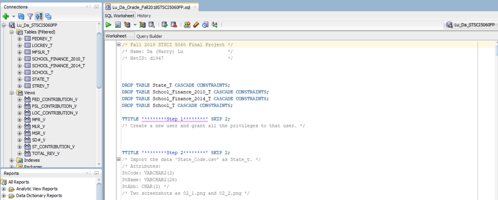